# Multiple Linear Regression: A Macro-Augmented Factor Model of NVIDIA’s Daily Returns

Author

Jan Zika

Published

June 25, 2026

## Research Question

**Which broad market, style, sector, and macroeconomic forces move NVIDIA’s daily stock return, and how much of that return do they jointly explain?**

NVIDIA (NVDA) is one of the most heavily traded stocks in the market, and its day-to-day moves are widely treated as a barometer for the technology and semiconductor sectors. This analysis asks how much of NVIDIA’s daily return is *systematic* — driven by forces that move the whole market — versus *idiosyncratic* — specific to the company itself. The answer matters to anyone holding or hedging the stock: it tells them what NVIDIA is really exposed to, and how much of its risk could in principle be diversified or hedged away.

The outcome is NVIDIA’s daily **excess return** (its return above the risk-free rate). The seven predictors span the market itself, two investment *style* factors (size and value), a *sector* factor, and three *macroeconomic* signals (the yield-curve slope, the corporate credit spread, and market-wide volatility).

## Dataset and Variables

**Source.** All data is pulled programmatically through public market-data APIs. Daily adjusted closing prices come from a market-price API; the macroeconomic and interest-rate series come from the U.S. Federal Reserve’s FRED API. A small R pipeline (`R/update_data.R`) fetches every series, caches it, and assembles the clean daily panel used here.

**What each row represents.** One **trading day**. Each row pairs NVIDIA’s return for that day with the value of every market, style, sector, and macro factor on the same day.

**Number of observations.** The model is estimated on **1778 trading days**, spanning **2019-01-03** to **2026-06-23**.

**Variables.**

| Role | Variable | What it represents |
| --- | --- | --- |
| Outcome | **NVDA excess return** | NVIDIA’s daily return minus the risk-free rate. |
| Predictor 1 | **Market** | The total stock market’s excess return (a broad-market ETF minus the risk-free rate). This is the classic CAPM market factor. |
| Predictor 2 | **Size** | Small-cap return minus large-cap return. Positive when smaller companies outperform. |
| Predictor 3 | **Value** | Value-stock return minus growth-stock return. Positive when cheap “value” stocks beat fast-growing “growth” stocks. |
| Predictor 4 | **Sector** | The semiconductor sector’s return above the market. Captures chip-industry-specific moves. |
| Predictor 5 | **TermSpread** | The daily change in the 10-year-minus-3-month Treasury yield slope. A rising slope often signals improving growth expectations. |
| Predictor 6 | **CreditSpread** | The daily change in the Baa-corporate-minus-10-year-Treasury yield spread. A rising spread signals growing financial stress. |
| Predictor 7 | **Volatility** | The daily change in the VIX, the market’s “fear gauge.” |

The risk-free rate is the 3-month Treasury bill rate. The spreads and the VIX enter as **daily changes** rather than levels, so each predictor is a stationary daily signal that lines up naturally with a daily return.

## The Regression Model Equation

The general form of a multiple linear regression with seven predictors is:

$$Y = \beta_0 + \beta_1 X_1 + \beta_2 X_2 + \beta_3 X_3 + \beta_4 X_4
+ \beta_5 X_5 + \beta_6 X_6 + \beta_7 X_7 + \varepsilon$$

where $Y$ is the outcome, $\beta_0$ is the intercept, each $\beta_k$ is the coefficient on predictor $X_k$, and $\varepsilon$ is the error term. Written with our own variable names:

$$\text{NVDA excess} = \beta_0 + \beta_1\,\text{Market} + \beta_2\,\text{Size}
+ \beta_3\,\text{Value} + \beta_4\,\text{Sector}
+ \beta_5\,\text{TermSpread} + \beta_6\,\text{CreditSpread}
+ \beta_7\,\text{Volatility} + \varepsilon$$

After fitting the model, the estimated equation (using the actual coefficients computed below) is:

$$\widehat{\text{NVDA excess}} = 0.0012
+ 1.2620\,\text{Market}
-0.2921\,\text{Size}
-1.2461\,\text{Value}
+ 0.4872\,\text{Sector}
+ 0.0071\,\text{TermSpread}
-0.0272\,\text{CreditSpread}
+ 0.0001\,\text{Volatility}$$

## Running the Model in R

```r
model <- lm(NVDA_excess ~ Market + Size + Value + Sector +
              TermSpread + CreditSpread + Volatility, data = model_df)
summary(model)
```

```
Call:
lm(formula = NVDA_excess ~ Market + Size + Value + Sector + TermSpread +
    CreditSpread + Volatility, data = model_df)

Residuals:
      Min        1Q    Median        3Q       Max
-0.116217 -0.010002 -0.000778  0.008869  0.178616

Coefficients:
               Estimate Std. Error t value Pr(>|t|)
(Intercept)   0.0011541  0.0004219   2.736  0.00629 **
Market        1.2619994  0.0590491  21.372  < 2e-16 ***
Size         -0.2920758  0.0652969  -4.473  8.2e-06 ***
Value        -1.2461409  0.0617675 -20.175  < 2e-16 ***
Sector        0.4871791  0.0340904  14.291  < 2e-16 ***
TermSpread    0.0070930  0.0076457   0.928  0.35368
CreditSpread -0.0272118  0.0136976  -1.987  0.04712 *
Volatility    0.0001204  0.0003227   0.373  0.70917
---
Signif. codes:  0 '***' 0.001 '**' 0.01 '*' 0.05 '.' 0.1 ' ' 1

Residual standard error: 0.01773 on 1770 degrees of freedom
Multiple R-squared:  0.6986,    Adjusted R-squared:  0.6974
F-statistic: 586.1 on 7 and 1770 DF,  p-value: < 2.2e-16
```

```r
broom::tidy(model) |>
  mutate(across(where(is.numeric), \(x) round(x, 5))) |>
  kable(caption = "Estimated coefficients, standard errors, t-statistics, and p-values.")
```

Estimated coefficients, standard errors, t-statistics, and p-values.

| term | estimate | std.error | statistic | p.value |
| --- | --- | --- | --- | --- |
| (Intercept) | 0.00115 | 0.00042 | 2.73551 | 0.00629 |
| Market | 1.26200 | 0.05905 | 21.37203 | 0.00000 |
| Size | -0.29208 | 0.06530 | -4.47304 | 0.00001 |
| Value | -1.24614 | 0.06177 | -20.17471 | 0.00000 |
| Sector | 0.48718 | 0.03409 | 14.29080 | 0.00000 |
| TermSpread | 0.00709 | 0.00765 | 0.92771 | 0.35368 |
| CreditSpread | -0.02721 | 0.01370 | -1.98661 | 0.04712 |
| Volatility | 0.00012 | 0.00032 | 0.37303 | 0.70917 |

## Interpreting the Model Summary

### A. Coefficients

Each coefficient is the average change in NVIDIA’s daily excess return associated with a one-unit increase in that predictor, **holding the other six predictors constant**.

- **Market (1.2620).** Positive. When the market’s excess return rises by one unit, NVIDIA’s expected excess return rises by about 1.2620. A value above 1 means NVIDIA is a **high-beta** stock: it amplifies market moves, climbing more than the market in up days and falling more in down days.
- **Size (-0.2921).** Negative. When small-cap stocks beat large-caps, NVIDIA tends to lag slightly — consistent with NVIDIA trading like a large-cap.
- **Value (-1.2461).** Strongly negative. When value stocks beat growth stocks, NVIDIA falls. This is the model’s clearest style signal: NVIDIA behaves like a **growth** stock, moving opposite to the value-minus-growth factor.
- **Sector (0.4872).** Positive. Independent of the broad market, when semiconductors outperform, NVIDIA rises with its sector — exactly what we expect from a chip maker.
- **TermSpread (0.0071).** Small. A one-day steepening of the yield curve has little measured association with NVIDIA’s return once the other factors are held constant.
- **CreditSpread (-0.0272).** Negative. On days when the corporate credit spread widens — a sign of rising financial stress — NVIDIA tends to fall, even after accounting for the market.
- **Volatility (0.0001).** Very small once the market factor is in the model, because changes in the VIX and market returns carry overlapping information.

### B. P-values

```r
broom::tidy(model) |>
  transmute(term, estimate = round(estimate, 5), p.value = signif(p.value, 3),
            significant_5pct = ifelse(p.value < 0.05, "yes", "no")) |>
  kable(caption = "Which predictors show statistically significant relationships.")
```

Which predictors show statistically significant relationships.

| term | estimate | p.value | significant_5pct |
| --- | --- | --- | --- |
| (Intercept) | 0.00115 | 6.29e-03 | yes |
| Market | 1.26200 | 0.00e+00 | yes |
| Size | -0.29208 | 8.20e-06 | yes |
| Value | -1.24614 | 0.00e+00 | yes |
| Sector | 0.48718 | 0.00e+00 | yes |
| TermSpread | 0.00709 | 3.54e-01 | no |
| CreditSpread | -0.02721 | 4.71e-02 | yes |
| Volatility | 0.00012 | 7.09e-01 | no |

A small p-value is evidence that a predictor’s true coefficient is different from zero. The **market, size, value, and sector** factors are all highly significant (p-values far below 0.05): the data give strong evidence that each is genuinely related to NVIDIA’s return. The **credit spread** is significant at the 5% level, showing measurable sensitivity to financial-stress days. By contrast, the **term spread** and the **change in the VIX** are *not* statistically significant: once the market and sector factors are present, these two macro signals add no detectable independent relationship with NVIDIA’s daily return. A non-significant predictor does not prove there is no relationship — only that this data set shows no clear evidence of one.

### C. R-squared

The R-squared value is **0.699**, which means the model explains approximately **70%** of the day-to-day variation in NVIDIA’s excess return. In other words, roughly that share of NVIDIA’s daily moves is *systematic* — traceable to broad market, style, sector, and macro forces — while the remaining **30%** is **idiosyncratic**: specific to NVIDIA (company news, earnings, product announcements) and not captured by these factors.

### D. Adjusted R-squared

The adjusted R-squared is **0.697**. Adjusted R-squared penalizes the model for each extra predictor, so it only rises when a new variable earns its place. Here it is almost identical to the ordinary R-squared (0.699), telling us the seven predictors together are not padding the model with noise — the explanatory power is real and not an artifact of simply adding variables. The fact that the two values barely differ is a sign of a healthy, well-specified model.

## Residual Errors and Model Fit

A **residual** is the difference between the actual value and the model’s prediction:

$$\text{Residual} = \text{Actual} - \text{Predicted}$$

A residual tells us how far off the model was on a single day. A **positive** residual means the model **underpredicted** (NVIDIA did better than expected); a **negative** residual means it **overpredicted** (NVIDIA did worse than expected). For example, if NVIDIA’s actual excess return on a day was 3% and the model predicted 2%, the residual is +1%.

## Residual Plot

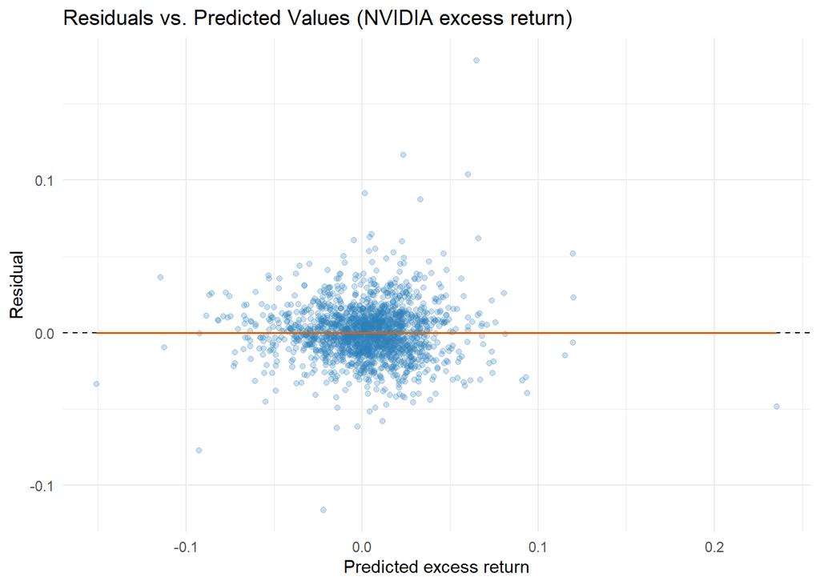

Residuals versus fitted values. A random horizontal band around zero indicates a well-behaved linear model.

```r
model_df$predicted <- fitted(model)
model_df$residuals <- residuals(model)

ggplot(model_df, aes(x = predicted, y = residuals)) +
  geom_point(alpha = 0.25, color = "#2c7fb8") +
  geom_hline(yintercept = 0, linetype = "dashed") +
  geom_smooth(se = FALSE, color = "#d95f02", linewidth = 0.7) +
  labs(title = "Residuals vs. Predicted Values (NVIDIA excess return)",
       x = "Predicted excess return", y = "Residual") +
  theme_minimal()
```

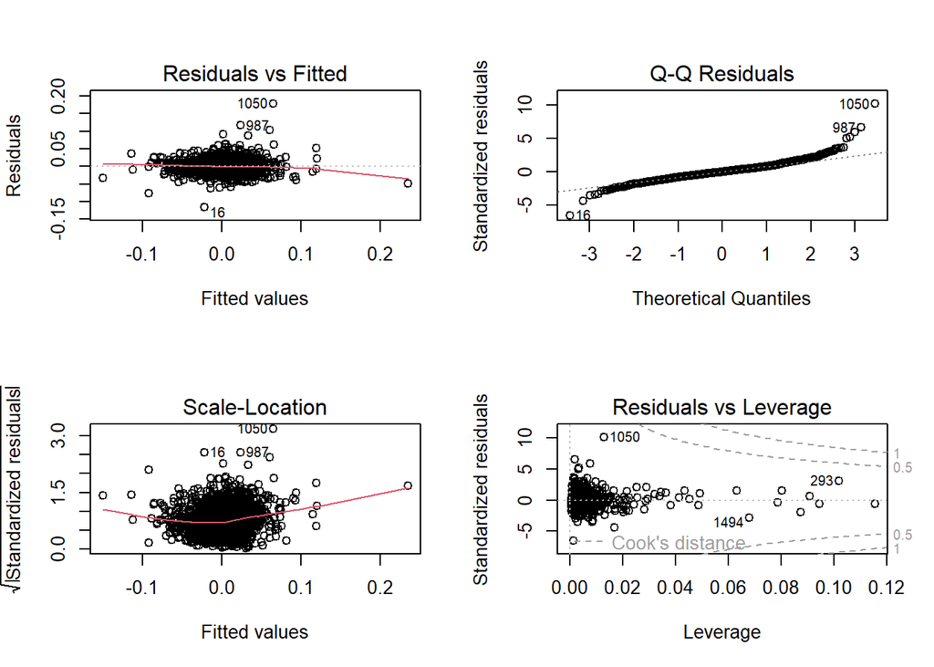

Standard regression diagnostics: residuals vs fitted, Normal Q-Q, scale-location, and residuals vs leverage.

```r
par(mfrow = c(2, 2)); plot(model); par(mfrow = c(1, 1))
```

The residuals are scattered fairly evenly above and below zero with no obvious trend across the range of predictions, so the orange smoother stays close to the dashed zero line — the **linearity** assumption looks reasonable. The visible feature is that the *spread* of the residuals widens on high-volatility days: large surprises cluster together, a familiar property of stock returns. The model does not systematically over- or under-predict in any region; its errors are roughly centered on zero everywhere, but it is least precise during turbulent market periods. The Q-Q plot shows heavier tails than a normal distribution — extreme days (large jumps) happen more often than a bell curve would predict.

## Model Assumptions and Limitations

```r
vif_vals <- car::vif(model)
bp <- lmtest::bptest(model)
dw_lag1 <- cor(head(residuals(model), -1), tail(residuals(model), -1))
```

- **Linearity.** The residual plot shows no strong curvature, so a straight-line relationship between the factors and NVIDIA’s return is a defensible approximation.
- **Residual randomness / independence.** The day-to-day autocorrelation of the residuals is only about -0.012, essentially zero, so the model is not leaving obvious predictable structure in its errors.
- **Outliers.** Extreme trading days (earnings surprises, market shocks) appear in the tails of the Q-Q plot. They do not dominate the fit given the large sample, but they are the days the model predicts least well.
- **Multicollinearity.** All variance-inflation factors are low (the largest is about 3.2, well under the usual threshold of 5), so the predictors are not redundant and each coefficient is estimated on its own distinct information.
- **Constant error variance.** A Breusch–Pagan test rejects constant variance (p < 0.001): the model’s errors are larger on volatile days. This **heteroskedasticity** does not bias the coefficients, but it means the reported standard errors slightly overstate the precision of the estimates. The large significances here are wide enough that this caveat does not change which factors matter.
- **Causation.** This model shows **association, not causation**. A significant coefficient means a factor *moves together with* NVIDIA’s return, not that it *causes* it. These factors and NVIDIA are all driven by the same underlying market forces in real time.

## The “So What?”

This model turns a noisy stream of daily NVIDIA returns into a clear story. About **70%** of NVIDIA’s daily movement is **systematic** — explained by where the broad market, growth-versus-value sentiment, and the semiconductor sector went that day. The single most important driver is the **market itself**: with a beta of 1.26, NVIDIA amplifies market moves, so it is a high-risk, high-reward holding rather than a defensive one. Its strong **growth** tilt (the large negative Value coefficient) and its clear **semiconductor** loading confirm what investors intuit — NVIDIA lives or dies with growth-stock sentiment and the chip cycle. The significant **credit spread** effect adds that NVIDIA also feels broad financial stress.

The practical takeaways: an investor who already owns the market and the semiconductor sector is, to a large degree, *already* holding NVIDIA’s risk — which is useful for hedging and diversification decisions. But the remaining **30%** of NVIDIA’s daily variation is **idiosyncratic** and cannot be explained by these broad factors; it is the part driven by company-specific news. Anyone using this model should remember three things: it explains *association*, not cause; it is least reliable precisely on the most turbulent days; and it describes the average relationship over this sample, which can shift as market regimes change. It is a strong tool for *understanding* what NVIDIA is exposed to — not a crystal ball for predicting tomorrow’s price.